# NDVI real data for SLOO

Cécile Hardouin

2026-03-12

```r
if (!require("remotes")) install.packages("remotes")
remotes::install_github("ropensci/MODIStsp")
library(terra)
library(geodata)
```

```r
library(ggplot2)
library(dplyr)
library(MODISTools)
library(MODIStsp)
library(spdep)
```

# Climate Data

### Variables

To ensure the dataset is easy to interpret, we are using the following combination:

Dependent Variable (Y): July NDVI (Peak greenness). NDVI stands for Normalized Difference Vegetation Index.

The NDVI is calculated using the Red and Near-Infrared (NIR) bands. It highlights the difference between visible red light and near-infrared light. This index is sensitive to both the vigor and the density of vegetation.

Explanatory Variable (X1): Elevation (Temperature lapse rate/cold effect). Explanatory Variable (X2): Aspect (Slope orientation). Explanatory Variable (X3): Slope. On steep slopes, water runoff is fast and soil is thin (low NDVI), whereas on flat areas, the soil is deeper and moister (higher NDVI).

Note that we could use Mean july temperature and/or Annual precipitation (global water availibilty). But this would induce very strong multicollinearity between Elevation, precipitation and Temperature. We choose to keep Elevation, which does not vary across time.

### Study Area Selection

A section of the Pyrenees covering fewer than 2,000 pixels, approximately 45km by 45km. We are targeting the central Pyrenees, spanning the border between France (Pyrenees National Park) and Spain (Monte Perdido). This area is ideal as it excludes major metropolitan areas and offers a spectacular environmental gradient.

Study Area Coordinates:North-West Corner: $42.90^{\circ} \text{N}, 0^{\circ} \text{E}$South-East Corner: $42.60^{\circ} \text{N}, 0.4^{\circ} \text{E}$

Area Characteristics: Diverse topography with mild temperatures in the valleys and low to negative temperatures at high altitudes. No large cities, only isolated villages.

Vegetation: Agricultural zones and broadleaf forests, transitioning to barren rock at high elevations.

# Explanatory Variables

We are required to download the data at a 30 arc-second resolution (approximately 1km). Even if res = 2.5 is specified, the system defaults to 0.5 min (30s).

```r
# Area of interest
ext_region <- ext( 0, 0.4, 42.6, 42.90 )

#elevation
elev <- worldclim_tile(
  var = "elev",
  lon = 0.25,
  lat = 42.7,
  res = 0.5,
  path = "data"
)
elev <- crop(elev, ext_region)

# Aspect variable on the original raster (in degrees from 0 to 360)
# We use the elevation raster as input
aspect_raw <- terrain(elev, v = "aspect", unit = "degrees")

# Transformation into a "Southness Index" (Insolation proxy)
# The cosine is at its maximum (1) for South (180°) and minimum (-1) for North (0°)
southness <- -cos(aspect_raw * pi / 180)

# Slope (in raw degrees without transformation).
slope <- terrain(elev, v = "slope", unit = "degrees")


#Resolution and number of pixels
res(elev)
```

```
## [1] 0.008333333 0.008333333
```

```r
ncell(elev) #1728
```

```
## [1] 1728
```

### Visualisation

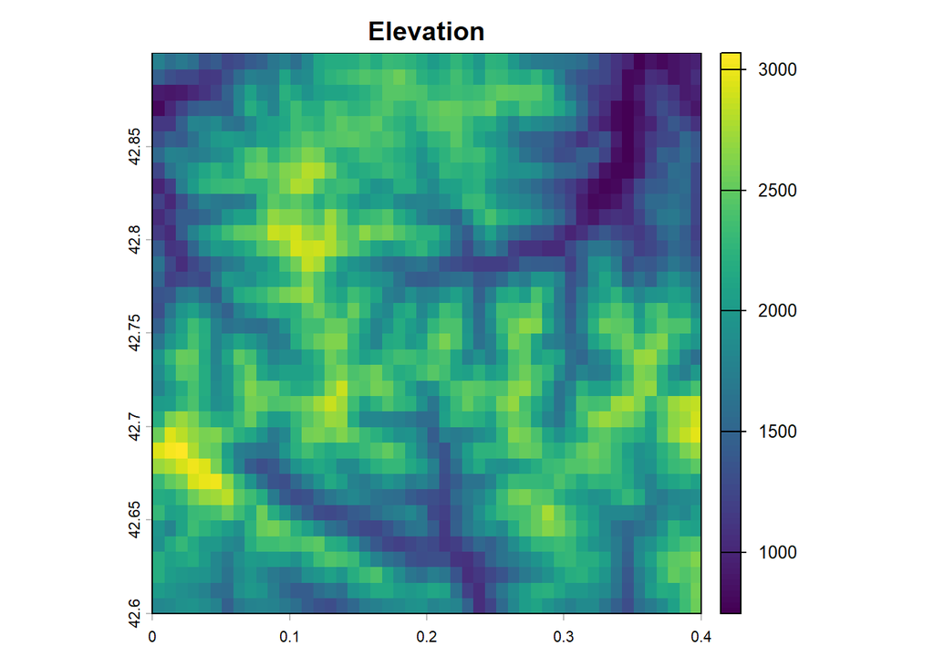

```r
plot(elev, main="Elevation")
```

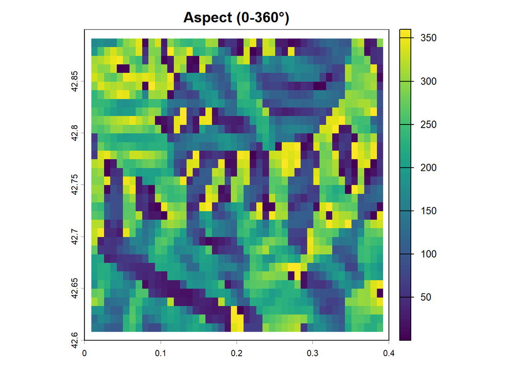

```r
plot(aspect_raw, main = "Aspect (0-360°)")   # 0° = North, 90° = East, 180° = South, 270° = West
```

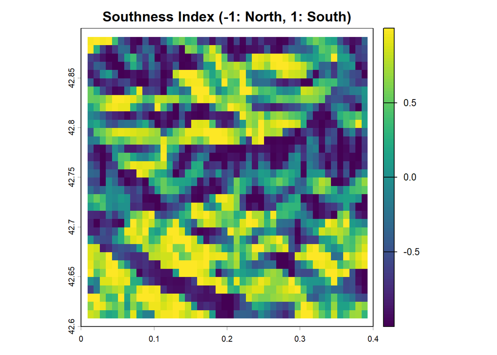

```r
plot(southness, main = "Southness Index (-1: North, 1: South)")
```

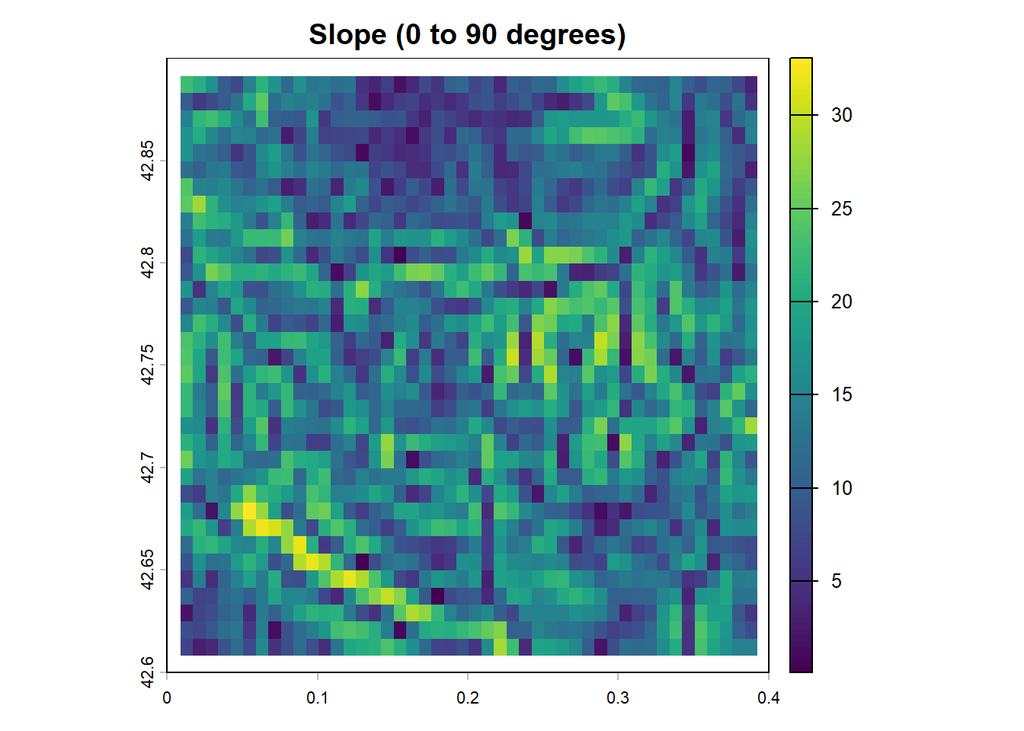

```r
plot(slope, main = "Slope (0 to 90 degrees)")
```

# NDVI data

```r
# 1. Download at 250m resolution (MOD13Q1)
# Note: km_lr/km_ab define the box size around the center point
ndvi_data_raw <- mt_subset(
  product = "MOD13Q1",
  band = "250m_16_days_NDVI",
  lat = 42.7,
  lon = 0.25,
  km_lr = 22.5, # Total width of approx 45km (22.5km on each side)
  km_ab = 24,   # Total height of approx 48km
  start = "2023-07-16",
  end = "2023-07-31"
)
```

```
##   |                                                                              |                                                                      |   0%  |                                                                              |=========================================================…
```

```r
# 2. Convert to Raster (terra format)
ndvi_250m <- mt_to_terra(ndvi_data_raw)

# 3. Resample to 1 km resolution: Aggregate by a factor of 4 (4 pixels of 250m = 1000m)
ndvi_1km <- aggregate(ndvi_250m, fact = 4, fun = mean, na.rm = TRUE)

# 4. Projection (WGS84)
target_crs <- "EPSG:4326"

# Project the raster: using "bilinear" interpolation for continuous NDVI data
ndvi_proj <- project(ndvi_1km, target_crs, method = "bilinear")

# 5. Final Cropping
ndvi_final <- crop(ndvi_proj, ext_region)

# 6. Summary and Visualization
summary(ndvi_final)
```

```
##   X2023.07.28
##  Min.   :0.1183
##  1st Qu.:0.5150
##  Median :0.6602
##  Mean   :0.6308
##  3rd Qu.:0.7742
##  Max.   :0.8722
```

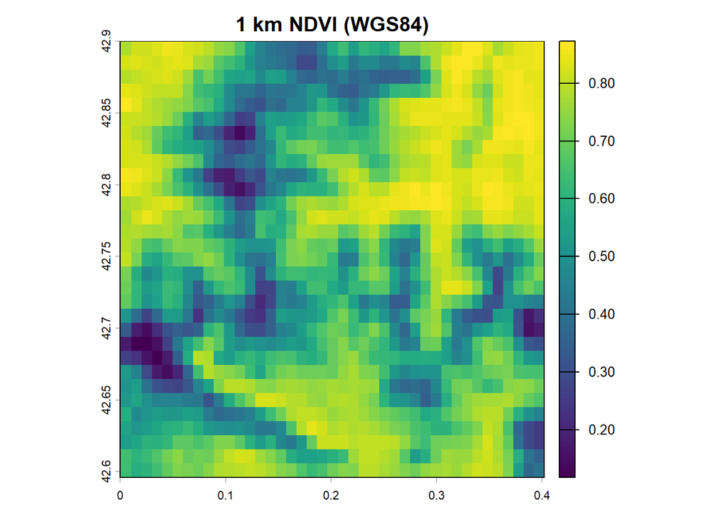

```r
plot(ndvi_final, main = "1 km NDVI (WGS84)")
```

```r
# Optional: Gap-filling (Interpolation)
# Fills NA values using a 3x3 moving window average
# ndvi_interpolated <- focal(ndvi_final, w = 3, fun = mean, na.rm = TRUE, NAonly = TRUE)
```

# Final dataset

We first start with grid alignment. The explanatory variables have a resolution of 0.0083°, while the NDVI is at 0.0099°.

```r
# 1. Use a climate variable as the "Reference Grid" (e.g., Elevation)
reference <- elev

# 2. Force the NDVI to match the reference resolution and extent
# We use 'bilinear' interpolation because NDVI is a continuous numerical value
ndvi_res <- resample(ndvi_final, reference, method = "bilinear")

# 3. Now that they have identical dimensions, we can stack them and create the final dataset for regression
mydata <- c(ndvi_res,  elev,  southness, slope)
#plot(mydata)
df_final <- as.data.frame(mydata, xy = TRUE, na.rm = TRUE)
colnames(df_final) <- c("lon", "lat", "ndvi", "elevation",  "southness", "slope")

# 5. Verification
summary(df_final)
```

```
##       lon              lat             ndvi          elevation
##  Min.   :0.0125   Min.   :42.61   Min.   :0.1326   Min.   : 749
##  1st Qu.:0.1042   1st Qu.:42.68   1st Qu.:0.5096   1st Qu.:1665
##  Median :0.2000   Median :42.75   Median :0.6478   Median :2046
##  Mean   :0.2000   Mean   :42.75   Mean   :0.6244   Mean   :1975
##  3rd Qu.:0.2958   3rd Qu.:42.82   3rd Qu.:0.7638   3rd Qu.:2319
##  Max.   :0.3875   Max.   :42.89   Max.   :0.8699   Max.   :3067
##    southness             slope
##  Min.   :-0.999997   Min.   : 0.1279
##  1st Qu.:-0.658505   1st Qu.: 9.1077
##  Median :-0.006118   Median :13.6208
##  Mean   :-0.008332   Mean   :13.8622
##  3rd Qu.: 0.656547   3rd Qu.:18.3698
##  Max.   : 0.999996   Max.   :33.0533
```

# OLS Regression

We consider the following model,
$$NDVI=\beta_0+\beta_1 Elevation +\beta_2 Southness +\beta_3 Slope +
\boldsymbol{\varepsilon}$$
The regression coefficients of Elevation and Slope are significant at the level 5%, the significance of Southness is more doubtful with a p-value of 5,4%.

As expected, the coefficient of Elevation is negative: Vegetation declines with increasing altitude.

```r
#variables correlations
cor(df_final[, c("ndvi", "elevation","southness","slope")])
```

```
##                  ndvi   elevation   southness       slope
## ndvi       1.00000000 -0.86732305 -0.05326339  0.11862930
## elevation -0.86732305  1.00000000  0.03490653 -0.04448946
## southness -0.05326339  0.03490653  1.00000000  0.01023260
## slope      0.11862930 -0.04448946  0.01023260  1.00000000
```

```r
# Simple linear model (OLS)
model <- lm(ndvi ~ elevation +southness + slope, data = df_final)
summary(model)
```

```
##
## Call:
## lm(formula = ndvi ~ elevation + southness + slope, data = df_final)
##
## Residuals:
##       Min        1Q    Median        3Q       Max
## -0.261873 -0.051578  0.006941  0.057496  0.193090
##
## Coefficients:
##               Estimate Std. Error t value Pr(>|t|)
## (Intercept)  1.211e+00  1.032e-02 117.374  < 2e-16 ***
## elevation   -3.117e-04  4.495e-06 -69.348  < 2e-16 ***
## southness   -5.705e-03  2.959e-03  -1.928   0.0541 .
## slope        2.085e-03  3.222e-04   6.472 1.29e-10 ***
## ---
## Signif. codes:  0 '***' 0.001 '**' 0.01 '*' 0.05 '.' 0.1 ' ' 1
##
## Residual standard error: 0.08035 on 1560 degrees of freedom
## Multiple R-squared:  0.7592, Adjusted R-squared:  0.7588
## F-statistic:  1640 on 3 and 1560 DF,  p-value: < 2.2e-16
```

We compute the residuals after OLS estimation, and study their spatial autocorrelation. We run a Moran’s test with the 8 nearest neighbours neighbourhood. We use $k=8$ neighbours to mimic a ‘Queen’ contiguity on a grid. Note that although we are using longitude/latitude (degrees), kNN remains robust as it identifies the closest points regardless of the distance unit.

The Moran’s index values is 0.75 and the test concludes clearly that residuals are spatially correlated.

```r
df_final$residuals <- residuals(model)

# We run a Moran's test with the 8nn neighbourhood.
coords <- as.matrix(df_final[, c("lon", "lat")])
nb <- knn2nb(knearneigh(coords, k = 8))
listw <- nb2listw(nb, style = "W")#Convert to a spatial weights list (W-style: row-standardized)

#  Perform the Moran's I test on OLS residuals
test_moran <- lm.morantest(model, listw)
print(test_moran)
```

```
##
##  Global Moran I for regression residuals
##
## data:
## model: lm(formula = ndvi ~ elevation + southness + slope, data =
## df_final)
## weights: listw
##
## Moran I statistic standard deviate = 59.994, p-value < 2.2e-16
## alternative hypothesis: greater
## sample estimates:
## Observed Moran I      Expectation         Variance
##     0.7498619290    -0.0016740775     0.0001569221
```

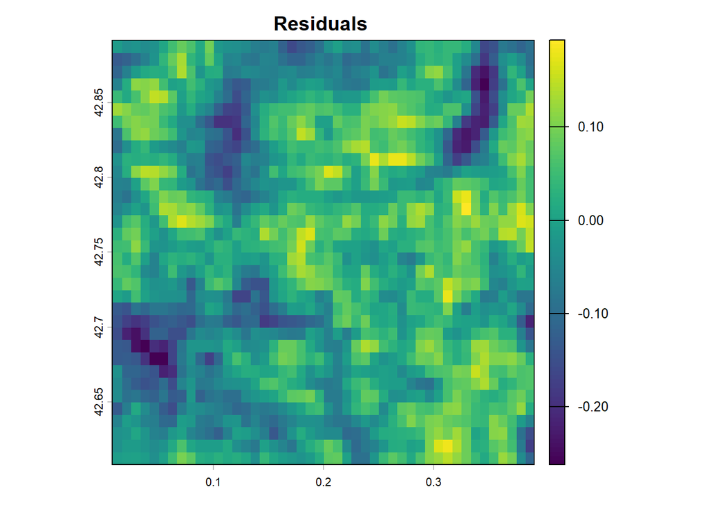

```r
#map of the residuals
res_map <- rast(df_final[, c("lon", "lat", "residuals")], type="xyz", crs=crs(elev))
plot(res_map,   main = "Residuals ")
```